# 光子关联与双光子干涉：同一套装置，两种物理机制

量子光学导论 · 第九讲

光子关联与双光子干涉

同一套装置，两种物理机制

李梓民 · 中南大学物理学院

zimin.li@csu.edu.cn

# 本讲导读

1. 01

### 比较一样亮的光

   把两束光分别接入同一装置。亮度相同，探测记录仍可能不同。
2. 02

### 数两路同时出现的信号

   数两只探测器同时有信号的次数，判断它们是否比偶然碰上更常见。
3. 03

### 比较两次探测的时间间隔

   热光更容易接连被探测；单个原子发光后，需要再次激发。
4. 04

### 从两侧各送入一个光子

   两个光子从分束器两侧进入，条件合适时，会一起从同一端离开。
5. 05

### 错开两个光子的到达时间

   两个光子到达得越不同步，从两个输出端分开离开的机会越大。
6. 06

### 两路没有同时响的两种原因

   两路没有同时响，可能是只输入一个光子，也可能是双光子干涉。

# 从光子数统计走向探测信号

目录

CONTENTS

两束光一样亮，探测器留下的记录也会一样吗？

# 同样的平均光子数，不同的光子数涨落

回顾第八讲：比较三种平均光子数都为1的理想单模光场。

| 光场 | 光子数方差 | 每次测量的特点 |
| --- | --- | --- |
| 单光子态 $\|1\rangle$ | $0$ | 每次恰好一个光子 |
| 相干态 | $\bar n=1$ | Poisson随机涨落 |
| 单模热态 | $\bar n+\bar n^2=2$ | 光子数涨落更强 |

平均光强相同，光子数统计仍可不同。

怎样从探测器实际记录的信号中，看出这些差别？

# 从光子到探测器的记录

光子探测器探测到光子时，输出一个短电脉冲。记录一个脉冲，称为一次**探测事件**，也称一次**计数**。

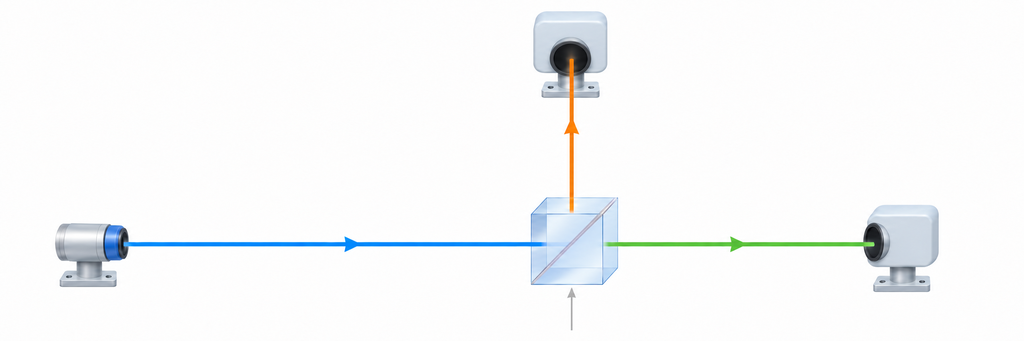

50:50分束器：单光子从 $a$ 端输入、$b$ 端为真空时，以相同概率到达 $c$ 或 $d$ 输出端。

本讲的开关型探测器，在每个短时间窗只记录**有信号／无信号**；一个或多个光子均可能触发一次信号。

# 思考题1：两只探测器会同时有信号吗？

每次输入一个光子，另一输入端为真空。 理想50:50分束器的两输出端各放一只理想探测器。

两路同时记录到信号的概率是多少？

光子到达每个输出端的概率均为 $1/2$。

B。一个光子触发一侧理想探测器，两路探测事件互斥。

# 发送单光子与双光子，比较探测记录

理想50:50分束器；一个或两个光子从同一输入端进入，另一端为真空。

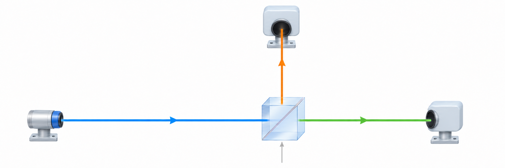

发送光子后，比较两侧的探测记录。

总试次0

两只探测器都有信号0

双光子试次中该比例—

先比较单光子与双光子输入。图示到达光子数；开关型探测器只报告有／无信号。

# 同一输入端的两个光子，有一半机会分开

用 $|n_a,n_b\rangle_{ab}$ 依次记录两个输入端的光子数。

固定输入 $|2,0\rangle_{ab}$：$a$ 端两个光子，$b$ 端真空。理想50:50分束器对此输入的预测如下。

[figure not shown]

同端双光子分束的三种输出概率。

两个输出端各一个光子的概率为 $1/2$，两只探测器都会有信号。

# 同端双光子分束的输出态

输入 $|2,0\rangle_{ab}=(a^\dagger)^2|0,0\rangle/\sqrt2$，取 $a^\dagger\to(c^\dagger+d^\dagger)/\sqrt2$。

不同输出模式的产生算符对易，两交叉项合为 $2c^\dagger d^\dagger$。

$$\begin{aligned}
|2,0\rangle_{ab}
&\to\frac{(c^\dagger+d^\dagger)^2}{2\sqrt2}|0,0\rangle\\
&=\frac12|2,0\rangle_{cd}+\frac1{\sqrt2}|1,1\rangle_{cd}+\frac12|0,2\rangle_{cd}.
\end{aligned}$$

各项概率为 $1/4,\ 1/2,\ 1/4$，总和为1。

这里的两光子来自同一个输入端；后半讲将改变这一条件。

# Hanbury Brown–Twiss（HBT）实验

待测光源接入分束器，另一输入端为真空，两输出仍接D₁、D₂。

两只探测器按**同一组短时间窗**记录：有信号记1，无信号记0。  
示例中，同一列对应同一时间窗。

| 记录 | 窗口1 | 窗口2 | 窗口3 | 窗口4 | 窗口5 | 窗口6 | 窗口7 | 窗口8 |
| --- | --- | --- | --- | --- | --- | --- | --- | --- |
| D₁ | 1 | 0 | 1 | 0 | 1 | 1 | 0 | 1 |
| D₂ | 0 | 1 | 1 | 0 | 0 | 1 | 1 | 0 |

**单路计数：** 分别数每行有信号的窗口，D₁有5次，D₂有4次。

**符合计数：** 数两只都有信号的窗口。窗口3、6满足，共2次。

# 用同一装置比较两种光源

先把光源A接入分束器，用D₁、D₂记录；再换成同样亮的B。 保持装置和窗长不变，每个光源测1000个窗口。下面是示例记录。

| 记录项目 | 光源A | 光源B |
| --- | --- | --- |
| D₁单路计数 | 200次 | 200次 |
| D₂单路计数 | 200次 | 200次 |

**先判断：** 仅凭这些单路计数，能分辨光源A和B吗？

| 再比较符合计数 | 光源A | 光源B |
| --- | --- | --- |
| 同一窗内两只都有信号 | 10次 | 80次 |

单路计数无法区分这两组记录，符合计数显示了它们的统计差别。

# 从符合计数到二阶关联

目录

CONTENTS

实际符合次数，要与什么基准比较？

# 思考题2：独立随机事件的符合基准

1000个等长窗口；  
两路各有200次信号。  
假设两路事件相互独立，平均预期符合多少次？

独立事件满足 $P_{12}=P_1P_2$；  
每路产生信号的概率均为 $0.2$。

C。$1000\times0.2\times0.2=40$ 次。有限样本的实际次数会有波动。

# 把实际符合次数除以独立预期

单路计数不同，独立预期也不同；比较实际符合是各自独立预期的多少倍。

在 $N$ 个窗口中，单路信号数为 $N_1,N_2$，符合数为 $N_{12}$。  
各路概率 $P_1=N_1/N$、$P_2=N_2/N$；双路概率 $P_{12}=N_{12}/N$。

$$R=\frac{P_{12}}{P_1P_2}
=\frac{N\,N_{12}}{N_1N_2}.$$

例：1000个窗口，两路各200次信号，独立预期为40次。

| 实际符合数 | 归一化比值 $R$ | 相对独立基准 |
| --- | --- | --- |
| 10次 | $0.25\lt1$ | 符合偏少 |
| 40次 | $1$ | 符合相当 |
| 80次 | $2\gt1$ | 符合偏多 |

# 思考题3：符合更多，关联就更强吗？

换一组记录，每束光各测1000个等长窗口。哪种判断正确？

| 光源 | 每路有信号 | 双路符合 |
| --- | --- | --- |
| A | 100次 | 20次 |
| B | 200次 | 40次 |

比较相对独立基准：

$$R=\frac{N\,N_{12}}{N_1N_2}.$$

C。A的独立基准为10次，B为40次；A的相对增强更明显。

# 零延迟二阶关联

前面用 $R$ 比较实际符合与独立预期。 要用它描述光本身的关联，需满足两个测量条件。

**弱探测**

对有贡献的光子数，单个光子的记录概率须足够低，使同一路同一窗内多个光子合并计数的影响可忽略。

**时间窗足够短**

两路使用同一组时间窗。 窗短到关联在窗内几乎不变。

满足上述条件，符合比值近似给出**零延迟二阶关联**：

$$g^{(2)}(0)\simeq R=\frac{P_{12}}{P_1P_2}.$$

“2”：比较两个探测事件；“0”：比较几乎同时发生的事件。

# 二阶关联与光子对数

从同一端输入波包相同的**单模脉冲**，光子数 $n$ 随脉冲变化。固定分束器、探测器和短窗；每个光子在两路被记录的概率为 $p_1,p_2$，不随 $n$ 改变。

给 $D_1$ 选一个：**$n$ 种**

$\longrightarrow$

给 $D_2$ 选另一个：**$n-1$ 种**

**共有 $n(n-1)$ 种配对。** 固定 $n$ 时，两颗不同光子的分束与记录按独立过程计算，每对概率为 $p_1p_2$。

弱探测下，先对光子数取平均，记 $\bar n=\langle n\rangle>0$：

$$P_1\simeq\bar n p_1,\qquad P_2\simeq\bar n p_2,\qquad P_{12}\simeq\langle n(n-1)\rangle p_1p_2.$$

$$\frac{P_{12}}{P_1P_2}\simeq\frac{\langle n(n-1)\rangle p_1p_2}{\bar n^2 p_1p_2}=\frac{\langle n(n-1)\rangle}{\bar n^2}=g^{(2)}(0).$$

单光子脉冲：$n=1$，没有可配对的光子，因此 $g^{(2)}(0)=0$。

# 由光子数方差计算三种光场的二阶关联

由第八讲的方差定义，先改写分子：

$$\langle n(n-1)\rangle=(\Delta n)^2+\bar n^2-\bar n.$$

$$g^{(2)}(0)=1+\frac{(\Delta n)^2-\bar n}{\bar n^2}.$$

| 光场 | 光子数方差 | 零延迟关联 | 物理含义 |
| --- | --- | --- | --- |
| 单光子态 $\|1\rangle$ | $0$ | $0$ | 没有可符合的光子对 |
| 相干态 | $\bar n$ | $1$ | 等于独立随机基准 |
| 单模热态 | $\bar n+\bar n^2$ | $2$ | 符合相对增强 |

现在改看持续发光的光源：相近时刻的事件为何增强或受抑制，关联又能保持多久？

## 补充：从探测概率到光子对数

固定波包与探测设置；每个光子的两路记录概率为 $p_1,p_2$。 概率包含分束、效率和短窗份额；弱探测要求 $np_1,np_2\ll1$。

固定 $n$，按独立弱探测计算：

$$P_1\simeq np_1,\qquad P_2\simeq np_2,\qquad P_{12}\simeq n(n-1)p_1p_2.$$

对不同脉冲的光子数取平均：

$$P_1\simeq\bar n p_1,\qquad P_2\simeq\bar n p_2,\qquad P_{12}\simeq\langle n(n-1)\rangle p_1p_2.$$

代回符合比值，共同的探测因子相消：

$$R=\frac{P_{12}}{P_1P_2}\simeq\frac{\langle n(n-1)\rangle p_1p_2}{\bar n^2 p_1p_2}
=\frac{\langle n(n-1)\rangle}{\bar n^2}=g^{(2)}(0).$$

# 聚束与反聚束的物理图像

目录

CONTENTS

为什么有些光的探测事件集中出现，有些则需要等待？

# 光子聚束

**光子聚束**：探测到一个光子后，短时间内再次探测到光子的机会高于相隔很久时。

以热光为例：光强随时间起伏，分束后的两路一起变亮、变暗。

[figure not shown]

同一光源的明暗涨落共同影响两个探测器。

探测到光子，更可能正处在明亮时段。 亮度起伏持续一段时间，因此紧接着再探测到光子的机会也较高。

# 观察探测事件在时间上的分布

示例记录：两种强度条件，各42次探测、观察时长相同。每条竖线代表一次探测。

分成12个等长时段，格下为探测次数

曲线表示设定的光强；固定总计数，按光强分布抽样探测时刻。

强度起伏使探测机会随时间改变。  
多次记录中，明亮时段的平均计数更多，暗淡时段更少。

# 光子反聚束

与聚束相反，**光子反聚束**表现为：探测到一个光子后，短时间内再次探测到光子的机会低于相隔很久时。

以持续受激发的单个原子为例（$g$ 为基态，$e$ 为激发态）：

[figure not shown]

单原子的发光循环：从基态激发，发出光子回到基态，再次激发。

原子发光后回到基态，需再次激发才能再发光。 这段等待抑制了短时间内接连发光，形成反聚束。

# 延迟二阶关联

两次探测相隔多久，仍有统计关联？用两路事件的时间差 $\tau$ 来比较。

[figure not shown]

两路时间记录与选定的一对事件时间差。

把 $D_2$ 的计数窗口相对 $D_1$ 平移 $\tau$，统计两窗都有信号的符合次数。 沿用弱探测、短时间窗条件，将它除以独立预期，得到 $g^{(2)}(\tau)$。

**短延迟**

聚束使再次探测的机会增加；  
反聚束使再次探测的机会减少。

**长延迟**

相隔远超光源的关联时间后， 两次探测趋于独立，$g^{(2)}(\tau)\to1$。

# 聚束与反聚束的时间关联曲线

单模热光2.00

相干光1.00

单发射体0.00

纵轴：二阶关联，独立基准为1。

横轴的1：各光源自身的一个关联时间。

延迟／关联时间0.00

示意模型：单模热光；单发射体忽略背景光、按单指数恢复。

相对于独立基准1：热光在零延迟附近形成峰，单发射体形成谷。 延迟增大后两者趋近1；相干光始终保持1。

# 思考题4：热光为什么出现聚束？

| 光场 | 零延迟关联 |
| --- | --- |
| 理想单模热光 | 高于独立基准 |

哪种解释符合刚才的物理图像？

C。两路共享同一光源的明暗起伏，因此探测事件有正关联。

# 回看HBT实验：从光强起伏到探测关联

留意光强的起伏怎样体现在两路探测记录中。

[video not shown]

# Hong–Ou–Mandel（HOM）双光子干涉

目录

CONTENTS

Hong–Ou–Mandel（HOM）实验：保留装置，改为两端各输入一个光子。

# 两个光子从同一端输入，或从两端分别输入

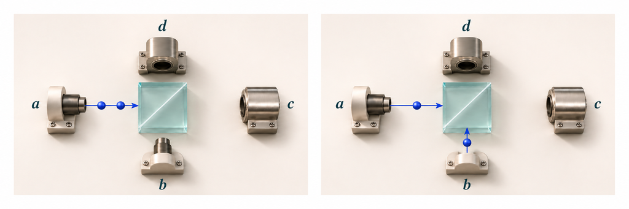

左图两个光子从a输入，右图a和b各输入一个。

**同端输入** $|2,0\rangle_{ab}$

两输出端各一个的概率为 $1/2$。

**双端输入** $|1,1\rangle_{ab}$

两个数字依次为 $a$、$b$ 端的光子数。

# 思考题5：先建立独立粒子的预测

两个独立的经典粒子分别从两输入端进入。 每个粒子各有 $1/2$ 概率透射或反射。

符合概率是多少？

两个都透射，或两个都反射，均会在两输出端各留下一个粒子。

C。两种过程各有概率 $1/4$，独立粒子的符合概率为 $1/2$。

# 两种过程通向“两输出端各一个”

除输入端口外，两光子的状态完全相同，且同时到达；输出端记为 $c,d$。

**TT · 两光子都透射****RR · 两光子都反射**

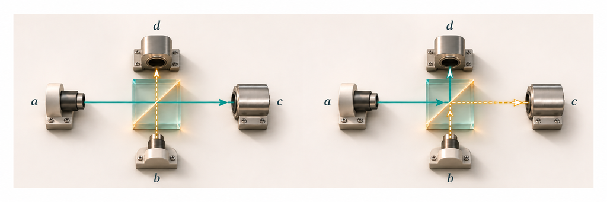

两种符合过程：TT为a到c及b到d，RR为a到d及b到c。

TT：$a\to c$、$b\to d$；RR：$a\to d$、$b\to c$。

TT和RR在每个输出端留下的光子状态相同，因此先相加概率幅。

# 思考题6：最终态能区分TT与RR吗？

| 除输入端口外，两光子的状态 | 到达分束器 |
| --- | --- |
| 完全相同 | 同时 |

比较TT与RR对应的“两输出端各一个”最终态。

最终态中是否有信息，标出哪个光子来自哪个输入端？

B。两种过程都留下两端各一个、光子状态相同的最终态。

# 分束器改变概率幅，也带来相对相位

$a,b$ 为输入模式，$c,d$ 为输出模式。  
沿用第七讲：$a^\dagger$ 在模式 $a$ 中增加一个光子，其他模式类似。

取一种无损50:50分束器相位约定：

$$\begin{aligned}a^\dagger&\longrightarrow\frac{c^\dagger+d^\dagger}{\sqrt2},\\[18pt]
b^\dagger&\longrightarrow\frac{c^\dagger-d^\dagger}{\sqrt2}.\end{aligned}$$

| 单光子通道 | 概率幅 |
| --- | --- |
| $a\to c$ | $+1/\sqrt2$ |
| $a\to d$ | $+1/\sqrt2$ |
| $b\to c$ | $+1/\sqrt2$ |
| $b\to d$ | $-1/\sqrt2$ |

四条通道的概率均为 $1/2$；计算干涉时，还须保留概率幅的相对正负号。

# 两条符合概率幅恰好相消

一条双光子过程的概率幅，等于其中两个单光子转换概率幅的乘积。

| 双光子过程 | 两个单光子概率幅相乘 | 符合概率幅 |
| --- | --- | --- |
| 都透射TT | $(+1/\sqrt2)(-1/\sqrt2)$ | $-1/2$ |
| 都反射RR | $(+1/\sqrt2)(+1/\sqrt2)$ | $+1/2$ |

[figure not shown]

TT与RR的符合概率幅大小相同、符号相反。

$$P_{\mathrm{coinc}}=\left|-\frac12+\frac12\right|^2=0.$$

理想不可区分双光子输入，抑制了“两端各一个”的输出。

# 思考题7：为什么两个输出端不会各有一个光子？

理想不可区分双光子分别从两输入端进入，TT与RR通向同一最终态。

| 过程 | TT | RR |
| --- | --- | --- |
| 概率幅 | $-1/2$ | $+1/2$ |
| 概率幅模平方 | $1/4$ | $1/4$ |

为何最终符合概率可以为零？

C。相消的是概率幅。可区分过程的概率相加，给出 $1/2$。

# 两个光子共同从一个输出端离开

展开前面的分束器变换并归一化，得到理想HOM输出态：

$$|1,1\rangle_{ab}\longrightarrow
\frac{|2,0\rangle_{cd}-|0,2\rangle_{cd}}{\sqrt2}.$$

[figure not shown]

HOM输出分布：c端两个、各端一个、d端两个的概率为一半、零、一半。

两种同端输出保持相干叠加；测量时各以 $50\%$ 出现。

## 补充：HOM输出态与归一化

输入 $a^\dagger b^\dagger|0,0\rangle$，代入前面的分束器变换：

$$\begin{aligned}
|\psi_{\mathrm{out}}\rangle
&=\tfrac12(c^\dagger+d^\dagger)(c^\dagger-d^\dagger)|0,0\rangle\\
&=\tfrac12\big[(c^\dagger)^2-c^\dagger d^\dagger\\
&\qquad +d^\dagger c^\dagger-(d^\dagger)^2\big]|0,0\rangle.
\end{aligned}$$

不同模式产生算符对易，$[c^\dagger,d^\dagger]=0$，交叉项相消。

利用 $(c^\dagger)^2|0,0\rangle=\sqrt2|2,0\rangle$，得到

$$|\psi_{\mathrm{out}}\rangle=\frac{|2,0\rangle-|0,2\rangle}{\sqrt2}.$$

# HOM凹陷与不可区分性

目录

CONTENTS

保持其他条件相同，让一个光子晚一点到达，符合概率会怎样变化？

# 改变光子的到达时间，怎样记录符合？

HOM每次试验：两个输入端各发送一个光子，作为同一输入光子对。

光子的到达时间有一定分布；描述它的概率幅包络称为时间波包。

计数窗覆盖同一光子对中两个波包的到达范围；两输出端均有记录，就计为一次符合。

| 改变的时间量 | 实验操作 |
| --- | --- |
| HBT探测时间差 | 在已有记录中比较两次探测的间隔 |
| HOM输入延迟 | 调整一个输入光路，使两个波包错开 |

充分错开：延迟远大于波包宽度；计数窗仍覆盖同一对光子的两次到达。

# 时间波包充分错开，符合概率回到一半

两光子偏振相同、频谱与波包形状匹配，只改变输入延迟。

[figure not shown]

相同、部分重叠和充分错开的两个时间波包示意。

| 两输入光子的关系 | 完全重叠 | 部分重叠 | 充分错开 |
| --- | --- | --- | --- |
| 符合概率 | $0$ | 介于 $0$ 与 $1/2$ | 趋近 $1/2$ |

充分错开且 $a$ 先到时：TT对应 $c$ 早、$d$ 晚，RR对应 $c$ 晚、$d$ 早。

早晚次序区分两种输出状态；合并计数时，两项概率相加为 $1/2$。

部分重叠时，时间信息区分TT与RR的能力减弱，仍保留部分干涉。

# 扫描到达时间差，观察HOM凹陷

当前符合概率0.0%

固定波包形状等条件，只改变到达时间。移动滑块，观察符合概率。

输入延迟 $\tau/\sigma$：0.00

高斯时间波包形状相同；每次各输入一个光子，计数窗覆盖同一对光子。$\sigma$ 为波包宽度尺度。

同时到达时符合最少，充分错开时恢复到 $1/2$；延迟扫描中的谷称为**HOM凹陷**。

# 偏振不同，也会改变两光子的干涉

两光子同时到达，$a$ 为水平偏振、$b$ 为竖直偏振，二者相互正交。

分辨偏振可识别这两种状态；这里的探测器合并记录它们。

| 通向两端各一个的过程 | $c$ 端偏振 | $d$ 端偏振 |
| --- | --- | --- |
| TT | 水平 | 竖直 |
| RR | 竖直 | 水平 |

两种最终偏振态正交，符合概率为两项概率之和：$1/4+1/4=1/2$。

夹角介于同向与正交之间时，斜偏振可分成平行与正交分量：平行分量保留干涉，正交分量留下区分信息，凹陷谷底随之升高。

# 用可见度描述HOM凹陷的深度

测量时长与光源条件相同：充分错开时符合计数为 $C_{\max}$，谷底计数为 $C_{\min}$。

$$V=\frac{C_{\max}-C_{\min}}{C_{\max}}.$$

[figure not shown]

符合计数示意：充分错开为500次，谷底为100次。

充分错开时符合500次，谷底100次：

$$V=\frac{500-100}{500}=80\%.$$

偏振、频谱和波包不匹配会降低可见度；多光子成分与背景也会影响实验结果。

## 补充：用内部状态重叠描述HOM

两输入各一个纯单光子，内部态为归一化的 $|f\rangle,|g\rangle$。理想50:50分束器，探测器不分辨内部自由度。

### 内部态的重叠

TT与RR交换两输出端的内部态，两端的重叠相乘。

$$\begin{aligned}
M&=\langle f|g\rangle\langle g|f\rangle=|\langle f|g\rangle|^2,\\
0&\le M\le1,\qquad P_{\mathrm{coinc}}=\frac{1-M}{2}.
\end{aligned}$$

内部态相同时 $M=1$，正交时 $M=0$。

### 本讲的高斯波包模型

时间与偏振可分离，其他自由度匹配；$\tau$ 为输入延迟。

$$M=e^{-(\tau/\sigma)^2}\cos^2\theta.$$

宽度尺度 $\sigma$，偏振夹角 $\theta$。

固定偏振扫描延迟时，理想凹陷的可见度为 $V=\cos^2\theta$。

# 调节延迟与偏振，观察HOM凹陷

当前符合概率0.0%

整条延迟曲线可见度100%

固定偏振扫延迟，观察当前点；再改变偏振，比较整条曲线的深度。

输入延迟 $\tau/\sigma$：0.00偏振夹角：0°

各输入一个纯单光子；高斯时间波包形状相同，其他自由度匹配。$\sigma$ 为波包宽度尺度。

# 思考题8：同时到达，是否就有零符合？

理想50:50分束器中，两个光子各从一侧输入。  
同时到达，时间波包和频率相同，但偏振正交。  
探测器不分辨偏振，符合概率为多少？

C。TT与RR对应正交的最终偏振态；两项概率各为 $1/4$，总计 $1/2$。

# 回看HOM实验：双光子干涉怎样改变输出？

留意哪些条件决定两个光子能否发生干涉。

[video not shown]

# HBT与HOM的比较

目录

CONTENTS

相同的零符合记录，可以来自怎样不同的物理机制？

# HBT与HOM：统计关联和双光子干涉

| 比较 | HBT | HOM |
| --- | --- | --- |
| 输入 | 待测光从一端进入 | 两端各输入一个光子 |
| 主要问题 | 探测事件怎样关联 | 双光子过程能否干涉 |
| 典型零符合 | 单光子脉冲没有光子对 | 完全不可区分时，两条符合概率幅相消 |
| 延迟的含义 | 两次探测事件的间隔 | 两输入光子的到达时差 |

HBT热光聚束来自共同强度涨落；理想HOM干涉消除“两端各一个”的输出。

# 从光源统计到双光子干涉

**HBT：从光源统计到探测关联**

相同的平均光强，符合记录仍可不同。

热光的强度起伏使事件聚集；单发射体发光后需要再激发。

**HOM：从输入方式到量子干涉**

两端各输入一个不可区分光子，符合概率幅相消。

时间充分错开或偏振正交时，符合概率恢复为 $1/2$。

开头两路各200次的记录：实际符合10次与80次，分别是独立预期40次的 $1/4$ 与2倍。

解释一组符合记录，先说清输入态、探测方式与可区分条件。

下一讲转向场分量的涨落：能否让一个场分量的噪声低于真空水平？这将引出压缩光。

延伸阅读：[HBT，Nature 177, 27 (1956)](https://doi.org/10.1038/177027a0)；[HOM，PRL 59, 2044 (1987)](https://doi.org/10.1103/PhysRevLett.59.2044)。

# 一键三连

[figure not shown]